# An Investigation of the Exponential Distribution

Mark E. Drummond

2015-05-23

# Overview

We investigate the properties of the [exponential distribution](http://en.wikipedia.org/wiki/Exponential_distribution) and compare it with the expected theoretical results expressed by the [Central Limit Theorem](http://en.wikipedia.org/wiki/Central_limit_theorem).

## Requirements

1. Show the distribution of sample means and compare it to the theoretical mean of the distribution.
2. Show the distribution of sample variances and compare it to the theoretical variance of the distribution.
3. Show that the distribution is approximately normal.

# Simulations

The exponential distribution can be simulated in R using the rexp(*n*, *lambda*) function where *n* is the sample size and *lambda* ($\lambda$) is the rate parameter. Both the mean and the standard deviation of the exponential distribution are $\frac{1}{\lambda}$.

We run 1,000 simulations of the exponential distribution, using a sample size *n* of 40 and a rate parameter *lambda* of 0.2. For each simulation we record the mean and standard deviation of the simulated data and store all the results in data frame for further analysis.

```r
n <- 40        # Sample size
lambda <- 0.2  # Rate parameter
number_of_simulations <- 1000

theoretical_mean    <- 1 / lambda             # Theoretical mean
theoretical_std_dev <- 1 / lambda             # Theoretical standard deviation
theoretical_var     <- theoretical_std_dev^2  # Theoretical variance

sample_means          <- NULL
sample_variances      <- NULL
sample_std_deviations <- NULL

for (experiment in 1 : number_of_simulations) {
  sample <- rexp(n = n, rate = lambda)
  sample_means          <- c(sample_means, mean(sample))
  sample_variances      <- c(sample_variances, var(sample))
  sample_std_deviations <- c(sample_std_deviations, sd(sample))
}

sample_statistics <- data.frame(cbind(sample_means, sample_variances, sample_std_deviations))
names(sample_statistics) <- c("sample_means", "sample_variances", "sample_std_deviations")

summary(sample_statistics)
```

```
##   sample_means   sample_variances sample_std_deviations
##  Min.   :2.960   Min.   : 5.865   Min.   :2.422
##  1st Qu.:4.461   1st Qu.:17.312   1st Qu.:4.161
##  Median :4.984   Median :23.326   Median :4.830
##  Mean   :5.025   Mean   :25.463   Mean   :4.930
##  3rd Qu.:5.543   3rd Qu.:30.800   3rd Qu.:5.550
##  Max.   :7.911   Max.   :83.263   Max.   :9.125
```

# Results

## Expectations

The Central Limit Theorem tells us that the distribution of sample statistics tends towards the Normal distribution as the sample size and the number of samples (simulations) increases, regardless of the distribution of the original data, assuming the samples are independant and identically distributed ([iid](http://en.wikipedia.org/wiki/Independent_and_identically_distributed_random_variables)).

In other words, as we increase the sample size (*n*) and/or the number of simulations, we expect the distribution of the means and standard deviations of our samples to tend toward the normal, and the distribution of the sample variances to tend toward the population variance, despite our samples being drawn from the exponential distribution. Given enough simulations we expect the distribution of these sample statistics to be approximating Normally distributed.

In this specific case we expect

1. The sample means to be approximately normally distributed with the mean of the samples approximately equal to the theoretical mean of the exponential distribution.
2. The sample standard deviations to be approximately normally distributed with standard deviation of the samples approximately equal to the theoretical standard deviation of the exponential distribution.
3. The variance of the samples to be approximately equal to the theoretical variance of the exponential distribution.

## Sample Mean vs. Theoretical Mean

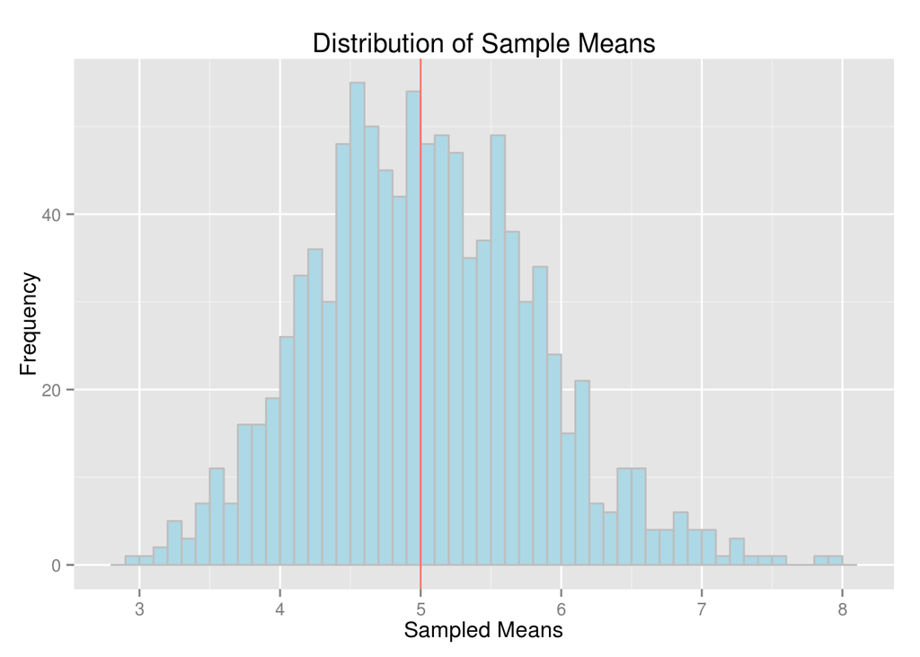

```r
library(ggplot2)

ggplot() +
  geom_histogram(data = sample_statistics,
                 aes(x = sample_statistics$sample_means),
                 binwidth = 0.1, fill = "lightblue", colour = "grey") +
  geom_vline(data = sample_statistics,
             aes(xintercept = 1/lambda, colour = "red")) +
  ggtitle("Distribution of Sample Means") +
  xlab("Sampled Means") + ylab("Frequency")
```

[figure not shown]

```r
ggplot() +
  geom_histogram(data = sample_statistics,
                 aes(x = sample_statistics$sample_variances),
                 binwidth = 0.1, fill = "lightblue", colour = "grey") +
  geom_vline(data = sample_statistics,
             aes(xintercept = 1/lambda, colour = "red")) +
  ggtitle("Distribution of Sample Variances") +
  xlab("Sampled Variances") + ylab("Frequency")
```

## Sample Standard Deviation vs. Theoretical Standard Deviation

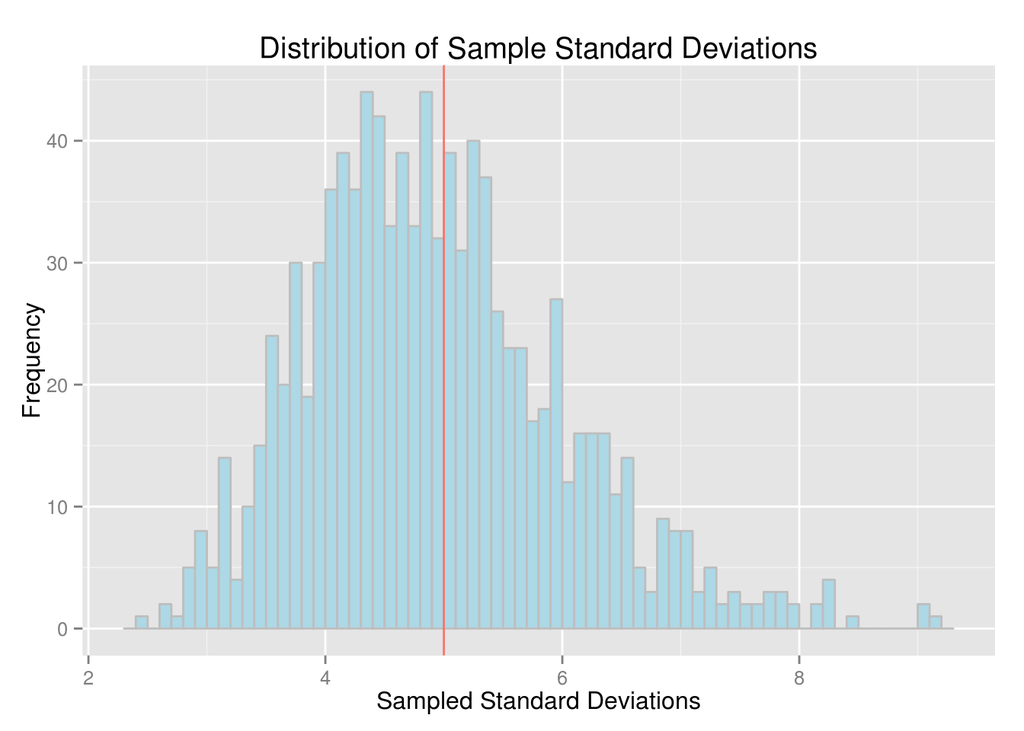

```r
ggplot() +
  geom_histogram(data = sample_statistics,
                 aes(x = sample_statistics$sample_std_deviations),
                 binwidth = 0.1, fill = "lightblue", colour = "grey") +
  geom_vline(data = sample_statistics,
             aes(xintercept = 1/lambda, colour = "red")) +
  ggtitle("Distribution of Sample Standard Deviations") +
  xlab("Sampled Standard Deviations") + ylab("Frequency")
```